# Optimizing Deposit Subscription Predictions with Decision Trees and Economic Metrics

Roberto Baca

25/07/2025

## Implementation of Decision Trees in R

Decision trees are like flowcharts used to predict outcomes in various fields. In machine learning, we use the CART technique (Classification And Regression Trees), a form of supervised learning where we seek a function that predicts the target variable based on predictor variables.

We will use the rpart package. RPART (Recursive Partitioning and Regression Trees) is a specific implementation of CART. This algorithm finds the best split of data into groups using rules, forming nodes and leaves in a tree.

### Advantages and Disadvantages

Decision trees offer interpretability and computational efficiency, but can be sensitive to the data sample and prone to overfitting.

### Objective of the Analysis

We will use the bank dataset from the liver package, which must be installed from CRAN if not already available.

The data is related to direct marketing campaigns of a Portuguese banking institution. The marketing campaigns were based on phone calls. Often, more than one contact with the same client was required to determine whether the product would be subscribed. The classification goal is to predict whether a client with a given profile will subscribe to a term deposit.

Decision trees will be used to predict the target variable “deposit” in the bank dataset from the liver package. The approaches are:

- Decision trees without balancing
- Upsampling
- Downsampling
- ROSE balancing
- Hybrid balancing
- No balancing but with hyperparameter tuning

The main metrics of each model will be compared, along with economic evaluation, to choose the model that fits best and maximizes profit.

### Load dataset and required libraries

```r
library(tidyverse)
library(rpart.plot)
library(rpart)
library(caret)

if (!require("liver")) install.packages("liver")
library(liver)

data("bank")
```

```r
# structure
str(bank)
```

```
## 'data.frame':    4521 obs. of  17 variables:
##  $ age      : int  30 33 35 30 59 35 36 39 41 43 ...
##  $ job      : Factor w/ 12 levels "admin.","blue-collar",..: 11 8 5 5 2 5 7 10 3 8 ...
##  $ marital  : Factor w/ 3 levels "divorced","married",..: 2 2 3 2 2 3 2 2 2 2 ...
##  $ education: Factor w/ 4 levels "primary","secondary",..: 1 2 3 3 2 3 3 2 3 1 ...
##  $ default  : Factor w/ 2 levels "no","yes": 1 1 1 1 1 1 1 1 1 1 ...
##  $ balance  : int  1787 4789 1350 1476 0 747 307 147 221 -88 ...
##  $ housing  : Factor w/ 2 levels "no","yes": 1 2 2 2 2 1 2 2 2 2 ...
##  $ loan     : Factor w/ 2 levels "no","yes": 1 2 1 2 1 1 1 1 1 2 ...
##  $ contact  : Factor w/ 3 levels "cellular","telephone",..: 1 1 1 3 3 1 1 1 3 1 ...
##  $ day      : int  19 11 16 3 5 23 14 6 14 17 ...
##  $ month    : Factor w/ 12 levels "apr","aug","dec",..: 11 9 1 7 9 4 9 9 9 1 ...
##  $ duration : int  79 220 185 199 226 141 341 151 57 313 ...
##  $ campaign : int  1 1 1 4 1 2 1 2 2 1 ...
##  $ pdays    : int  -1 339 330 -1 -1 176 330 -1 -1 147 ...
##  $ previous : int  0 4 1 0 0 3 2 0 0 2 ...
##  $ poutcome : Factor w/ 4 levels "failure","other",..: 4 1 1 4 4 1 2 4 4 1 ...
##  $ deposit  : Factor w/ 2 levels "no","yes": 1 1 1 1 1 1 1 1 1 1 ...
```

### Distribution of the Target Variable

The target variable is “deposit,” which is factorized.

We aim to determine the number of cases in the dataset where clients were contacted and subsequently subscribed to a deposit.

It is observed that the classes are highly imbalanced.

```r
prop.table(table(bank$deposit))
```

```
##
##      no     yes
## 0.88476 0.11524
```

### Dataset Partitioning

The dataset is split into training and testing sets.

```r
set.seed(42)

n <- nrow(bank)
train_indices <- sample(1:n, n * 0.7)

bank_train <- bank[train_indices, ]
bank_test <- bank[-train_indices, ]
```

We examine the distribution of the target variable in both the training and testing sets.

```r
prop.table(table(bank_test$deposit))
```

```
##
##        no       yes
## 0.8887251 0.1112749
```

```r
table(bank_train$deposit)
```

```
##
##   no  yes
## 2794  370
```

There is a class imbalance, with the “NO” class representing 89% of the total.

## Decision Trees

### A - Decision Trees Without Balancing

Apply the decision tree model to the dataset without balancing the classes:

```r
arboles <- rpart(formula = deposit ~ ., method = "class", data = bank_train)
```

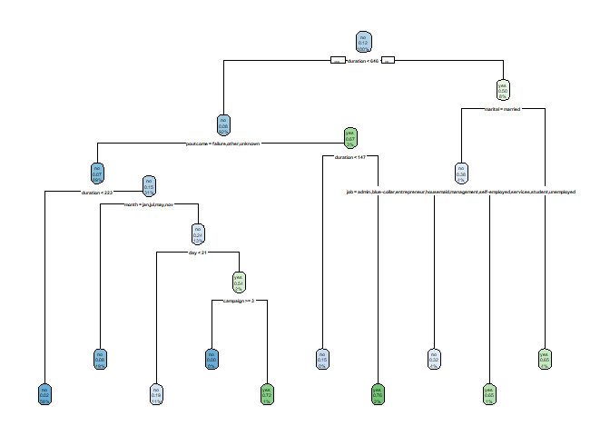

```r
# Visualize the tree
library(rpart.plot)

rpart.plot(arboles)
```

### Confusion Matrix

Make predictions on the test set and display the confusion matrix and metrics:

```r
predArbol1_train <- predict(arboles, newdata = bank_train, type = "prob")
predArbol1_test <- predict(arboles, newdata = bank_test, type = "prob")
```

```r
library(caret)

pred_test <- ifelse(predArbol1_test[, "yes"] > 0.5, "yes", "no")
pred_test <- factor(pred_test, levels = c("no", "yes"))
real_test <- factor(bank_test$deposit, levels = c("no", "yes"))

# Confusion matrix
cm <- confusionMatrix(pred_test, real_test, positive = "yes")
cm
```

```
## Confusion Matrix and Statistics
##
##           Reference
## Prediction   no  yes
##        no  1166   95
##        yes   40   56
##
##                Accuracy : 0.9005
##                  95% CI : (0.8833, 0.9159)
##     No Information Rate : 0.8887
##     P-Value [Acc > NIR] : 0.08891
##
##                   Kappa : 0.4017
##
##  Mcnemar's Test P-Value : 3.359e-06
##
##             Sensitivity : 0.37086
##             Specificity : 0.96683
##          Pos Pred Value : 0.58333
##          Neg Pred Value : 0.92466
##              Prevalence : 0.11127
##          Detection Rate : 0.04127
##    Detection Prevalence : 0.07074
##       Balanced Accuracy : 0.66885
##
##        'Positive' Class : yes
##
```

```r
# Metrics
acc <- cm$overall["Accuracy"]
sensitivity  <- cm$byClass["Sensitivity"]
specificity <- cm$byClass["Specificity"]
```

- Accuracy: shows the percentage of correct predictions.
- Sensitivity (True Positive Rate): percentage of actual positives correctly identified.
- Specificity: how well the model identifies true negatives.

### Economic Evaluation of the Unbalanced Model

We define the following costs and revenues:

```r
costo_contacto <- 100
ingreso_venta <- 3000
```

```r
cm$table
```

```
##           Reference
## Prediction   no  yes
##        no  1166   95
##        yes   40   56
```

```r
TP <- cm$table["yes", "yes"]
TN <- cm$table["no", "no"]
FP <- cm$table["yes", "no"]
FN <- cm$table["no", "yes"]
```

```r
contactos_realizados <- TP + FP # all cases predicted as "yes"
Resultado <- ingreso_venta * TP - costo_contacto * contactos_realizados

cat("Total Profit = $", Resultado, "\n", "Contacts made =", contactos_realizados, "\n", "TP (successful sales) =", TP, "\n")
```

```
## Total Profit = $ 158400
##  Contacts made = 96
##  TP (successful sales) = 56
```

Unbalanced Model Summary

| Modelo | Ganancia_Total | Contactos_Realizados | TP |
| --- | --- | --- | --- |
| Unbalanced | 158400 | 96 | 56 |

## B - Decision Trees with Upsampling

Upsampling consists of randomly duplicating examples from the minority class to equalize the number of observations with the majority class.

Returns a new data frame with a column named Class (new target variable).

```r
library(caret)

# Check class distribution before balancing
antes <- prop.table(table(bank_train$deposit))
antes
```

```
##
##        no       yes
## 0.8830594 0.1169406
```

```r
# Apply upsampling and verify new distribution
bank_train_upsampled <- upSample(x = select(bank_train, -deposit), y = bank_train$deposit)
despues <- prop.table(table(bank_train_upsampled$Class))
despues
```

```
##
##  no yes
## 0.5 0.5
```

```r
str(bank_train_upsampled)
```

```
## 'data.frame':    5588 obs. of  17 variables:
##  $ age      : int  58 30 35 45 44 83 58 49 30 50 ...
##  $ job      : Factor w/ 12 levels "admin.","blue-collar",..: 6 2 8 5 1 6 5 1 8 4 ...
##  $ marital  : Factor w/ 3 levels "divorced","married",..: 2 3 2 1 2 2 2 2 3 3 ...
##  $ education: Factor w/ 4 levels "primary","secondary",..: 2 2 2 3 2 2 3 2 2 4 ...
##  $ default  : Factor w/ 2 levels "no","yes": 1 1 1 1 1 1 1 1 1 1 ...
##  $ balance  : int  11 6900 195 2096 2403 0 9339 14440 209 0 ...
##  $ housing  : Factor w/ 2 levels "no","yes": 1 1 2 1 2 1 2 2 2 1 ...
##  $ loan     : Factor w/ 2 levels "no","yes": 1 1 1 1 1 1 1 1 1 1 ...
##  $ contact  : Factor w/ 3 levels "cellular","telephone",..: 1 1 1 1 1 1 2 1 3 2 ...
##  $ day      : int  11 21 17 21 28 18 18 21 6 28 ...
##  $ month    : Factor w/ 12 levels "apr","aug","dec",..: 2 10 1 10 5 8 10 10 9 6 ...
##  $ duration : int  270 816 203 127 180 140 52 60 30 118 ...
##  $ campaign : int  1 1 1 1 2 10 3 1 2 8 ...
##  $ pdays    : int  -1 -1 -1 100 -1 -1 172 -1 -1 -1 ...
##  $ previous : int  0 0 0 2 0 0 3 0 0 0 ...
##  $ poutcome : Factor w/ 4 levels "failure","other",..: 4 4 4 1 4 4 2 4 4 4 ...
##  $ Class    : Factor w/ 2 levels "no","yes": 1 1 1 1 1 1 1 1 1 1 ...
```

```r
# Retrain the model with balanced data
arbol_upsampled <- rpart(formula = Class ~ ., method = "class", data = bank_train_upsampled)

# Predictions
pred_test_up <- predict(arbol_upsampled, newdata = bank_test, type = "prob")
pred_test_classes_up <- ifelse(pred_test_up[, "yes"] > 0.5, "yes", "no")
pred_test_classes_up <- factor(pred_test_classes_up, levels = levels(bank_test$deposit))

# Confusion Matrix
cm_up <- confusionMatrix(pred_test_classes_up, bank_test$deposit, positive = "yes")
cm_up
```

```
## Confusion Matrix and Statistics
##
##           Reference
## Prediction  no yes
##        no  985  39
##        yes 221 112
##
##                Accuracy : 0.8084
##                  95% CI : (0.7864, 0.829)
##     No Information Rate : 0.8887
##     P-Value [Acc > NIR] : 1
##
##                   Kappa : 0.3657
##
##  Mcnemar's Test P-Value : <2e-16
##
##             Sensitivity : 0.74172
##             Specificity : 0.81675
##          Pos Pred Value : 0.33634
##          Neg Pred Value : 0.96191
##              Prevalence : 0.11127
##          Detection Rate : 0.08254
##    Detection Prevalence : 0.24539
##       Balanced Accuracy : 0.77924
##
##        'Positive' Class : yes
##
```

```r
# Metrics
acc_up <- cm_up$overall["Accuracy"]
sensitivity_up <- cm_up$byClass["Sensitivity"]
specificity_up <- cm_up$byClass["Specificity"]
```

### Economic Evaluation of the Upsampled Model

```r
cm_up$table
```

```
##           Reference
## Prediction  no yes
##        no  985  39
##        yes 221 112
```

```r
TP_upsampled  <- cm_up$table["yes", "yes"]
TN_upsampled <- cm_up$table["no", "no"]
FP_upsampled <- cm_up$table["yes", "no"]
FN_upsampled <- cm_up$table["no", "yes"]
```

```r
contactos_realizados_upsampled <- TP_upsampled + FP_upsampled # todos lso casos predichos como "yes"
Resultado_upsampled <- ingreso_venta * TP_upsampled - costo_contacto * contactos_realizados_upsampled

cat("Total Profit with Upsampling = $", Resultado_upsampled, "\n", "Contacts made =", contactos_realizados_upsampled, "\n", "TP (successful sales) =", TP_upsampled, "\n")
```

```
## Total Profit with Upsampling = $ 302700
##  Contacts made = 333
##  TP (successful sales) = 112
```

Upsampling Summary

| Modelo | Ganancia_Total | Contactos_Realizados | TP |
| --- | --- | --- | --- |
| Upsampling | 302700 | 333 | 112 |

## C - Decision Trees with Downsampling

Downsampling involves randomly removing observations from the majority class to match the number of observations in the minority class.

The result includes a Class column (replacing deposit as the target variable).

```r
library(caret)

# Check distribution before downsampling
antes <- prop.table(table(bank_train$deposit))
antes
```

```
##
##        no       yes
## 0.8830594 0.1169406
```

```r
# Apply downsampling
bank_train_downsampled <- downSample(x = select(bank_train, -deposit), y = bank_train$deposit)
despues <- prop.table(table(bank_train_downsampled$Class))
despues
```

```
##
##  no yes
## 0.5 0.5
```

```r
# Retrain with downsampled data
arbol_downsampled <- rpart(formula = Class ~ ., method = "class", data = bank_train_downsampled)

# Predictions
pred_test_down <- predict(arbol_downsampled, newdata = bank_test, type = "prob")
pred_test_classes_down <- ifelse(pred_test_down[, "yes"] > 0.5, "yes", "no")
pred_test_classes_down <- factor(pred_test_classes_down, levels = levels(bank_test$deposit))

# Confusion Matrix
cm_down <- confusionMatrix(pred_test_classes_down, bank_test$deposit, positive = "yes")
cm_down
```

```
## Confusion Matrix and Statistics
##
##           Reference
## Prediction  no yes
##        no  939  27
##        yes 267 124
##
##                Accuracy : 0.7833
##                  95% CI : (0.7605, 0.805)
##     No Information Rate : 0.8887
##     P-Value [Acc > NIR] : 1
##
##                   Kappa : 0.3538
##
##  Mcnemar's Test P-Value : <2e-16
##
##             Sensitivity : 0.82119
##             Specificity : 0.77861
##          Pos Pred Value : 0.31714
##          Neg Pred Value : 0.97205
##              Prevalence : 0.11127
##          Detection Rate : 0.09138
##    Detection Prevalence : 0.28814
##       Balanced Accuracy : 0.79990
##
##        'Positive' Class : yes
##
```

```r
# Metrics
acc_down <- cm_down$overall["Accuracy"]
sensitivity_down <- cm_down$byClass["Sensitivity"]
specificity_down <- cm_down$byClass["Specificity"]
```

### Economic Evaluation of the Downsampled Model

```r
cm_down$table
```

```
##           Reference
## Prediction  no yes
##        no  939  27
##        yes 267 124
```

```r
TP_downsampled  <- cm_down$table["yes", "yes"]
TN_downsampled <- cm_down$table["no", "no"]
FP_downsampled <- cm_down$table["yes", "no"]
FN_downsampled <- cm_down$table["no", "yes"]
```

```r
contactos_realizados_downsampled <- TP_downsampled + FP_downsampled # todos lso casos predichos como "yes"
Resultado_downsampled <- ingreso_venta * TP_downsampled - costo_contacto * contactos_realizados_downsampled

cat("Total Profit with Downsampling = $", Resultado_downsampled, "\n", "Contacts made =", contactos_realizados_downsampled, "\n", "TP (successful sales) =", TP_downsampled, "\n")
```

```
## Total Profit with Downsampling = $ 332900
##  Contacts made = 391
##  TP (successful sales) = 124
```

Downsampling Summary

| Modelo | Ganancia_Total | Contactos_Realizados | TP |
| --- | --- | --- | --- |
| Downsampling | 332900 | 391 | 124 |

## D - Decision Trees with ROSE Balancing (Synthetic Data Generation)

When classes are highly imbalanced (e.g., many “no” vs. few “yes”), models may struggle to learn patterns of the minority class.

ROSE (Random OverSampling Examples) generates synthetic examples rather than duplicating records.

```r
if (!require("ROSE")) install.packages("ROSE")
library(ROSE)

mayoritarios <- sum(bank_train$deposit == "no")

bank_train_rose <- ROSE(deposit ~ ., data=bank_train, N = 2 * mayoritarios, seed=123)$data

table(bank_train_rose$deposit)
```

```
##
##   no  yes
## 2813 2775
```

```r
# Train on ROSE-balanced data
arbol_rose <- rpart(formula = deposit ~ ., method = "class", data = bank_train_rose)

# Predictions
pred_test_rose <- predict(arbol_rose, newdata = bank_test, type = "prob")
pred_test_classes_rose <- ifelse(pred_test_rose[, "yes"] > 0.5, "yes", "no")
pred_test_classes_rose <- factor(pred_test_classes_rose, levels = levels(bank_test$deposit))

# Confusion Matrix
cm_rose <- confusionMatrix(pred_test_classes_rose, bank_test$deposit, positive = "yes")
cm_rose
```

```
## Confusion Matrix and Statistics
##
##           Reference
## Prediction  no yes
##        no  965  29
##        yes 241 122
##
##                Accuracy : 0.801
##                  95% CI : (0.7788, 0.822)
##     No Information Rate : 0.8887
##     P-Value [Acc > NIR] : 1
##
##                   Kappa : 0.3768
##
##  Mcnemar's Test P-Value : <2e-16
##
##             Sensitivity : 0.8079
##             Specificity : 0.8002
##          Pos Pred Value : 0.3361
##          Neg Pred Value : 0.9708
##              Prevalence : 0.1113
##          Detection Rate : 0.0899
##    Detection Prevalence : 0.2675
##       Balanced Accuracy : 0.8041
##
##        'Positive' Class : yes
##
```

```r
# Metrics
acc_rose <- cm_rose$overall["Accuracy"]
sensitivity_rose <- cm_rose$byClass["Sensitivity"]
specificity_rose <- cm_rose$byClass["Specificity"]
```

### Economic Evaluation of ROSE

```r
cm_rose$table
```

```
##           Reference
## Prediction  no yes
##        no  965  29
##        yes 241 122
```

```r
TP_rose  <- cm_rose$table["yes", "yes"]
TN_rose <- cm_rose$table["no", "no"]
FP_rose <- cm_rose$table["yes", "no"]
FN_rose <- cm_rose$table["no", "yes"]
```

```r
contactos_realizados_rose <- TP_rose + FP_rose # todos lso casos predichos como "yes"
Resultado_rose <- ingreso_venta * TP_rose - costo_contacto * contactos_realizados_rose

cat("Total Profit with ROSE = $", Resultado_rose, "\n", "Contacts made =", contactos_realizados_rose, "\n", "TP (successful sales) =", TP_rose, "\n")
```

```
## Total Profit with ROSE = $ 329700
##  Contacts made = 363
##  TP (successful sales) = 122
```

ROSE Summary

| Modelo | Ganancia_Total | Contactos_Realizados | TP |
| --- | --- | --- | --- |
| ROSE | 329700 | 363 | 122 |

## E - Decision Trees with Hybrid Balancing

Hybrid balancing combines:

- Downsampling of the majority class to reduce imbalance.
- ROSE to generate synthetic examples and restore balance.

```r
set.seed(123)

tab    <- table(bank_train$deposit)
n_no   <- tab["no"]
n_yes  <- tab["yes"]
target <- floor((n_no + n_yes) / 2)

# Step 1: Downsample to target
N_under   <- target + n_yes

data_under <- ovun.sample(
  deposit ~ ., data = bank_train,
  method = "under",
  N      = N_under,
  seed   = 123
)$data

# Step 2: ROSE generation to 2 * target
N_final <- 2 * target
p_yes   <- 0.5

bank_train_h <- ROSE(
  deposit ~ ., data = data_under,
  N = N_final, p = p_yes,
  seed = 123
)$data

table(bank_train_h$deposit)
```

```
##
##   no  yes
## 1598 1566
```

```r
# Train on hybrid data
arbol_h <- rpart(formula = deposit ~ ., method = "class", data = bank_train_h)

# Predictions
pred_test_h <- predict(arbol_h, newdata = bank_test, type = "prob")
pred_test_classes_h <- ifelse(pred_test_h[, "yes"] > 0.5, "yes", "no")
pred_test_classes_h <- factor(pred_test_classes_h, levels = levels(bank_test$deposit))

# Confusion Matrix
cm_h <- confusionMatrix(pred_test_classes_h, bank_test$deposit, positive = "yes")
cm_h
```

```
## Confusion Matrix and Statistics
##
##           Reference
## Prediction  no yes
##        no  933  32
##        yes 273 119
##
##                Accuracy : 0.7752
##                  95% CI : (0.7521, 0.7972)
##     No Information Rate : 0.8887
##     P-Value [Acc > NIR] : 1
##
##                   Kappa : 0.3308
##
##  Mcnemar's Test P-Value : <2e-16
##
##             Sensitivity : 0.78808
##             Specificity : 0.77363
##          Pos Pred Value : 0.30357
##          Neg Pred Value : 0.96684
##              Prevalence : 0.11127
##          Detection Rate : 0.08769
##    Detection Prevalence : 0.28887
##       Balanced Accuracy : 0.78086
##
##        'Positive' Class : yes
##
```

```r
# Metrics
acc_h <- cm_h$overall["Accuracy"]
sensitivity_h <- cm_h$byClass["Sensitivity"]
specificity_h <- cm_h$byClass["Specificity"]
```

### Economic Evaluation of the Hybrid Model

```r
cm_h$table
```

```
##           Reference
## Prediction  no yes
##        no  933  32
##        yes 273 119
```

```r
TP_h  <- cm_h$table["yes", "yes"]
TN_h <- cm_h$table["no", "no"]
FP_h <- cm_h$table["yes", "no"]
FN_h <- cm_h$table["no", "yes"]
```

```r
contactos_realizados_h <- TP_h + FP_h # todos lso casos predichos como "yes"
Resultado_h <- ingreso_venta * TP_h - costo_contacto * contactos_realizados_h

cat("Total Profit with Hybrid = $", Resultado_h, "\n", "Contacts made =", contactos_realizados_h, "\n", "TP (successful sales) =", TP_h, "\n")
```

```
## Total Profit with Hybrid = $ 317800
##  Contacts made = 392
##  TP (successful sales) = 119
```

Hybrid Summary

| Modelo | Ganancia_Total | Contactos_Realizados | TP |
| --- | --- | --- | --- |
| Hybrid | 317800 | 392 | 119 |

## F - Decision Trees WITHOUT Class Balancing but with Hyperparameter Optimization

The key hyperparameters typically used to control the structure of a decision tree include:

- **minsplit**: The minimum number of observations required to attempt a split at a node.
- **maxdepth**: The maximum depth allowed for the tree.
- **minbucket**: The minimum number of observations that must be contained in any terminal (leaf) node.
- **cp (complexity parameter)**: Used to control tree complexity via pruning, helping to reduce overfitting and improve generalization.

It is important to carefully tune the values of minsplit, minbucket, cp, and maxdepth to allow the algorithm to effectively capture patterns associated with the minority class. Lower values of minsplit and cp can lead to more granular splits, which may help identify subtle patterns relevant to the minority class. However, caution must be taken to avoid overfitting.

```r
set.seed(42)

# Define training control with cross-validation
train_control <- trainControl(method = "cv", number = 5)  # 5-fold cross-validation

# Define the grid of hyperparameters to test
grid <- expand.grid(
  cp = seq(0.001, 0.05, by = 0.005)
)

# Train the model with hyperparameter tuning for cp
arbol_hp <- train(
  deposit ~ ., data = bank_train,
  method = "rpart",
  trControl = train_control,
  tuneGrid = grid
)

# Extract the optimal cp value
mejor_cp <- arbol_hp$bestTune
mejor_cp
```

```
##      cp
## 6 0.026
```

```r
# Generate predictions
pred_test_hp <- predict(arbol_hp, newdata = bank_test, type = "prob")
pred_test_classes_hp <- ifelse(pred_test_hp[, "yes"] > 0.5, "yes", "no")
pred_test_classes_hp <- factor(pred_test_classes_hp, levels = levels(bank_test$deposit))

# Confusion Matrix
cm_hp <- confusionMatrix(pred_test_classes_hp, bank_test$deposit, positive = "yes")
cm_hp
```

```
## Confusion Matrix and Statistics
##
##           Reference
## Prediction   no  yes
##        no  1176  111
##        yes   30   40
##
##                Accuracy : 0.8961
##                  95% CI : (0.8786, 0.9118)
##     No Information Rate : 0.8887
##     P-Value [Acc > NIR] : 0.2071
##
##                   Kappa : 0.3136
##
##  Mcnemar's Test P-Value : 1.615e-11
##
##             Sensitivity : 0.26490
##             Specificity : 0.97512
##          Pos Pred Value : 0.57143
##          Neg Pred Value : 0.91375
##              Prevalence : 0.11127
##          Detection Rate : 0.02948
##    Detection Prevalence : 0.05158
##       Balanced Accuracy : 0.62001
##
##        'Positive' Class : yes
##
```

```r
# Metrics
acc_hp <- cm_hp$overall["Accuracy"]
sensitivity_hp <- cm_hp$byClass["Sensitivity"]
specificity_hp <- cm_hp$byClass["Specificity"]
```

### Profit Evaluation of the Hyperparameter-Tuned Model

```r
cm_hp$table
```

```
##           Reference
## Prediction   no  yes
##        no  1176  111
##        yes   30   40
```

```r
TP_hp <- cm_hp$table["yes", "yes"]
TN_hp <- cm_hp$table["no", "no"]
FP_hp <- cm_hp$table["yes", "no"]
FN_hp <- cm_hp$table["no", "yes"]
```

```r
contactos_realizados_hp <- TP_hp + FP_hp # all cases predicted as "yes"
Resultado_hp <- ingreso_venta * TP_hp - costo_contacto * contactos_realizados_hp

cat("Total Profit with Hyperparameters = $", Resultado_hp, "\n", "Contacts Made =", contactos_realizados_hp, "\n", "TP (Successful Sales) =", TP_hp, "\n")
```

```
## Total Profit with Hyperparameters = $ 113000
##  Contacts Made = 70
##  TP (Successful Sales) = 40
```

Hiperparámetros

| Modelo | Ganancia_Total | Contactos_Realizados | TP |
| --- | --- | --- | --- |
| Hiperparametros | 113000 | 70 | 40 |

## Results Comparison

### Model Comparison: Metrics and Economic Evaluation

- **Accuracy**: Indicates the proportion of correct predictions made by the model.
- **Sensitivity**: (also called True Positive Rate): Measures the model’s ability to correctly identify positive instances (i.e., actual subscribers).
- **Specificity**: (True Negative Rate): Assesses how well the model identifies actual negative cases.

```r
library(knitr)

resultados <- data.frame(Balanceo = c("No Balancing", "UpSampling", "DownSampling", "ROSE", "Hybrid", "Hyperparameters"),
                         Accuracy = c(acc, acc_up,acc_down, acc_rose, acc_h, acc_hp),
                         Sensitivity = c(sensitivity, sensitivity_up, sensitivity_down, sensitivity_rose, sensitivity_h, sensitivity_hp),
                         Specificity = c(specificity , specificity_up , specificity_down, specificity_rose, specificity_h, specificity_hp),
                          Contactos_Realizados = c(contactos_realizados, contactos_realizados_upsampled, contactos_realizados_downsampled, contactos_realizados_rose, contactos_realizados_h, contactos_realizados_hp),
                         TP = c(TP, TP_upsampled, TP_downsampled, TP_rose, TP_h, TP_hp),
                         Ganancia_Total = c(Resultado, Resultado_upsampled, Resultado_downsampled, Resultado_rose, Resultado_h, Resultado_hp))

# Sort by Total_Profit (descending)
resultados_ordenado <- resultados %>%
  arrange(desc(Ganancia_Total))

kable(resultados_ordenado, digits = 4, caption = "Profit Comparison Across All Models")
```

Profit Comparison Across All Models

| Balanceo | Accuracy | Sensitivity | Specificity | Contactos_Realizados | TP | Ganancia_Total |
| --- | --- | --- | --- | --- | --- | --- |
| DownSampling | 0.7833 | 0.8212 | 0.7786 | 391 | 124 | 332900 |
| ROSE | 0.8010 | 0.8079 | 0.8002 | 363 | 122 | 329700 |
| Hybrid | 0.7752 | 0.7881 | 0.7736 | 392 | 119 | 317800 |
| UpSampling | 0.8084 | 0.7417 | 0.8167 | 333 | 112 | 302700 |
| No Balancing | 0.9005 | 0.3709 | 0.9668 | 96 | 56 | 158400 |
| Hyperparameters | 0.8961 | 0.2649 | 0.9751 | 70 | 40 | 113000 |

```r
library(ggplot2)
library(plotly)

resultados_ordenado$Balanceo <- factor(resultados_ordenado$Balanceo, levels = resultados_ordenado$Balanceo)

bar <- ggplot(resultados_ordenado, aes(x = Balanceo, y = Ganancia_Total)) +
  geom_col(fill = "steelblue") +
  theme_minimal() +
  labs(title = "Total Profit by Sampling Technique",
       y = "Profit ($)", x = "Balancing Method") +
  theme(axis.text.x = element_text(angle = 45, hjust = 1))

ggplotly(bar)
```

[interactive chart not shown]

### Conclusions

Relying solely on an unbalanced model or hyperparameter tuning without addressing class imbalance may produce misleading results. High accuracy alone is not sufficient—these models fail at achieving the core business objective of effectively identifying new clients.